# Lecture #8: Measures of Uncertainty and of Skewness

STAT 200 – Introductory Statistics

Torin Quinlivan

tquinlivan@knox.edu

Knox College

January 13, 2026

## Today’s Objective

After today’s lecture, you should:

- calculate the following measures of spread:
  - variance and standard deviation ($s$ and $s^2$)
  - interquartile range (IQR)
  - coefficient of variation ($c_v$)
- determine if the data are “sufficiently skewed” using the Hildebrand ratio, $H$.
- determine what information each measure provides about the data.
- understand the empirical rule and Chebyshev’s inequality.

## Measures of Spread

In the previous lecture, we talked about how to mathematically describe the center of the data. But how do we define the uncertainty of the data?

For example, the datasets $\{ 1,5,9 \}$ and $\{ 4,5,6 \}$ have the same mean, median and mode. What is the difference between the two sets? How could I describe the difference?

## Measures of Spread

A measure of spread of data describes how similar or varied the set of observed values are for a particular data set. It is used to describe the variability in a sample or population.

**Examples:**

- standard deviation
- variance
- coefficient of variation
- range
- interquartile range (IQR)

## Variance, $s^2$

The variance, $s^2$, is an average (positive) distance to the center of the data set.

$$s^2 = \frac{1}{n-1} \sum_{i=1}^n \big( x_i - \bar{x} \big)^2$$

## Variance, $s^2$

Some notes on the variance:

- Since the calculation requires using the mean, the variance should only be used if the mean is meaningful.
- Mathematicians like this because variances add.
- The units of the variance is $units^2$.
- This is the *sample variance*. The *population variance* is denoted as $\sigma^2$.

The `R` function to calculate the variance is `var()`.

## Standard Deviation, $s$

The standard deviation, $s$, is an average (positive) distance to the center of the data set. Specifically, it’s the square root of the variance.

$$s = \sqrt{s^2} = \sqrt{\frac{1}{n-1} \sum_{i=1}^n \big( x_i - \bar{x} \big)^2}$$

## Standard Deviation, $s$

Some notes on the standard deviation:

- Since the calculation requires using the mean, the standard deviation should also only be used if the mean is meaningful.
- The standard deviation is usually preferred when conveying information, because it has the same units as the data.
- This is the *sample standard deviation*. The *population standard deviation* is denoted as $\sigma$.

The `R` function to calculate the standard deviation is `sd()`.

## Variance/Standard Deviation Example

Which of the two pairs have a greater standard deviation/variance?

$$\begin{aligned}[t]
\textrm{Set A:} \quad 1, 2, 3, 4, 5 \\
\textrm{Set B:} \quad 1, 1, 3, 5, 5
\end{aligned}$$

$$\begin{aligned}[t]
\textrm{Set A:} \quad 22, 25, 30, 35, 38 \\
\textrm{Set B:} \quad 61, 62, 71, 80, 81
\end{aligned}$$

$$\begin{aligned}[t]
\textrm{Set A:} \quad 15, 17, 19, 21, 23 \\
\textrm{Set B:} \quad 85, 87, 89, 91, 93
\end{aligned}$$

## Variance/Standard Deviation Example

**Example:** Find the sample variance and the sample standard deviation of the following data set:

$$\begin{aligned}
1, 2, 4, 5, 6, 8, 9
\end{aligned}$$

## Variance/Standard Deviation Example

**Example:** Find the sample variance and the sample standard deviation of the following data set:

$$\begin{aligned}
2.0, 1.7, 1.9, 1.5, 1.6, 1.9, 1.7, 3.0
\end{aligned}$$

## Coefficient of Variation, $c_v$

The **coefficient of variation**, $c_v$, is also an average distance from the values to the center. However, it is scaled by the mean of the data.

$$c_v = \frac{s}{\bar{x}}$$

## Coefficient of Variation, $c_v$

Some notes on the coefficient of variation:

- Since the calculation requires using the mean, the coefficient of variation should only be used if the mean is meaningful.
- The coefficient of variation is preferred when comparing variability between two variables.
- The coefficient of variation is unitless.

The `R` function to calculate the coefficient of variation is `cv()`.

## Interquartile Range (IQR)

The interquartile range (IQR), is the range of the middle 50% of the data. It is defined as the difference between the first and third quartiles.

$$IQR = Q_3 - Q_1$$

## Interquartile Range (IQR)

Some notes on the interquartile range:

- Since the calculation requires using the median (to find the quartiles), the interquartile range should only be used for numeric data.
- The length of the box in a box-and-whiskers plot represents the IQR.

The `R` function to calculate the interquartile range is `IQR()`.

## Interquartile Range (IQR) Example

Which set has the largest interquartile range (IQR)?

- Respiratory rates at rest (in breaths ber minute) of adults in group A:

$$\begin{aligned}
10, 12, 13, 14, 15, 16, 17, 18
\end{aligned}$$

- Respiratory rates at rest (in breaths ber minute) of adults in group B:

$$\begin{aligned}
11, 15, 17, 18, 19, 19 , 20
\end{aligned}$$

## Hildebrand Ratio, $H$

The **Hildebrand ratio**, $H$, is a *scaled measure of skewness* of the data. It relies on the difference between the mean and the median, as scaled by the standard deviation.

$$H = \frac{\bar{x} - \tilde{x}}{s}$$

## Hildebrand Ratio, $H$

The Hildebrand ratio is used to determine if the data are too skewed to use mean-based measures:

- If $H \ge 0.20$, then the data are *positively skewed (skewed to the right)*.
- If $H \le -0.20$, then the data are *negatively skewed (skewed to the left)*.
- Otherwise, the data are sufficiently symmetric.

The `R` function to calculate the Hildebrand ratio is `hildebrand.rule()`. This is included in Dr. Forsberg’s `R` functions that can be loaded.

## Geography Quiz Example

First we’ll look at a data set of scores on a geography quiz. Calculate and interpret the measures of center and the measures of spread.

The `R` code we’ll use here is:

```r
library(KnoxStats)
dt = read.csv("https://rfs.kvasaheim.com/data/geography.csv")
attach(dt)
```

## Geography Quiz Example

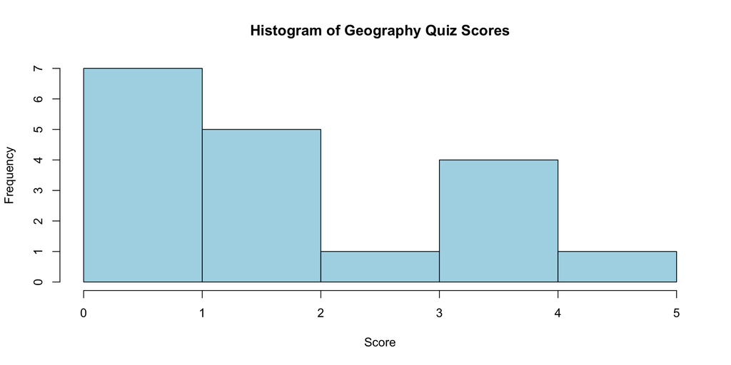

## Geography Quiz Example

Measures of Center:

- The mean is 1.944. (`mean(Score)`)
- The median is 2.000. (`median(Score)`)
- The mode is 0. (`modal(Score)`)

## Geography Quiz Example

Measures of Spread:

- The standard deviation is 1.7311. (`sd(Score)`)
- The IQR is 3.75. (`IQR(Score)`)
- The coefficient of variation is 0.8903. (`cv(Score)`)

Measures of Skewness:

- The Hildebrand ratio is -0.03. (`hildebrand.rule(Score)`)

## School Enrollment in 1990 Example

Let’s look at the school enrollment percentages for 1990 (`enroll90`) in the `crime` data.

The `R` code we’ll use here is:

```r
library(KnoxStats)
dt = read.csv("https://rfs.kvasaheim.com/data/crime.csv")
attach(dt)
```

## School Enrollment in 1990 Example

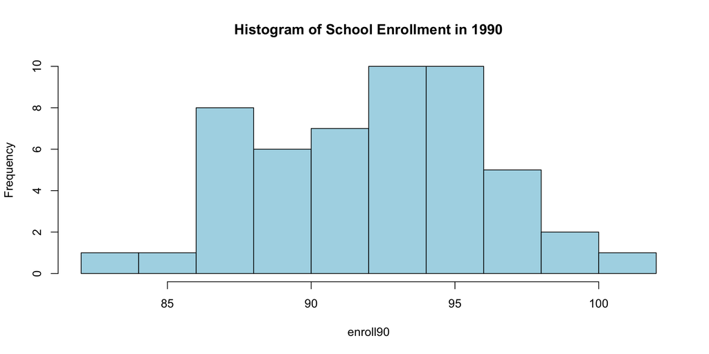

## School Enrollment in 1990 Example

Measures of Center:

- The mean is 92.06. (`mean(enroll90)`)
- The median is 92.60. (`median(enroll90)`)
- The mode is 92.60. (`modal(enroll90)`)

## School Enrollment in 1990 Example

Measures of Skewness:

- The Hildebrand ratio is -0.14. (`hildebrand.rule(enroll90)`)

## School Enrollment in 2000 Example

Let’s look at the school enrollment percentages for 2000 (`enroll00`) in the `crime` data instead.

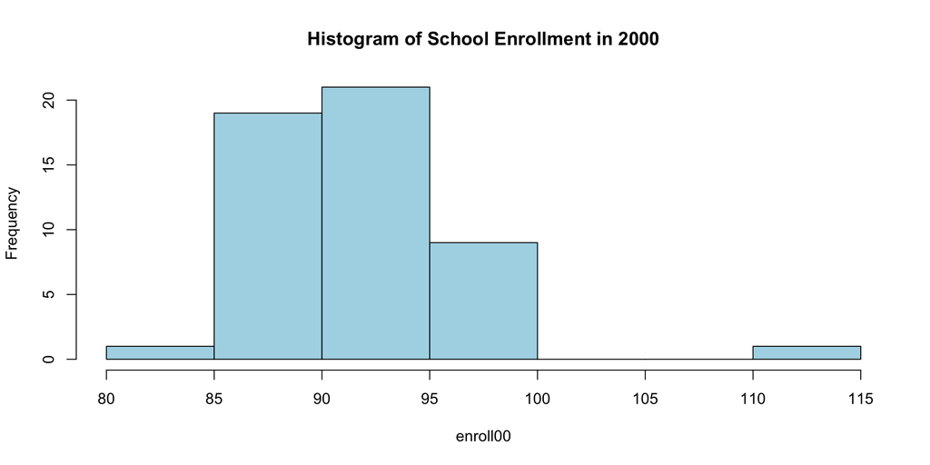

## School Enrollment in 2000 Example

Measures of Center:

- The mean is 91.75. (`mean(enroll00)`)
- The median is 91.00. (`median(enroll00)`)
- The data are multimodal. (`modal(enroll00)`)

## School Enrollment in 2000 Example

- The standard deviation is 4.53. (`sd(enroll00)`)
- The IQR is 5.10. (`IQR(enroll00)`)
- The coefficient of variation is 0.05. (`cv(enroll00)`)

Measures of Skewness:

- The Hildebrand ratio is 0.165. (`hildebrand.rule(enroll00)`)

## Violent Crime Rate in 2000 Example

Finally, let’s look at the violent crime rate in 2000 (`vcrime00`) in the `crime` data.

[figure not shown]

## Violent Crime Rate in 2000 Example

Measures of Center:

- The mean is 441.6. (`mean(vcrime00)`)
- The median is 383.8. (`median(vcrime00)`)

## Violent Crime Rate in 2000 Example

Measures of Spread:

- The standard deviation is 241.45. (`sd(vcrime00)`)
- The IQR is 268.25. (`IQR(vcrime00)`)
- The coefficient of variation is 0.547. (`cv(vcrime00)`)

Measures of Skewness:

- The Hildebrand ratio is 0.239. (`hildebrand.rule(vcrime00)`)

## The Empirical Rule

The standard deviation gives us information about intervals that contain “a certain amount” of the data. One of the most useful is the Empirical Rule.

It is also sometimes called the “68-95-99.7% Rule”

## The Empirical Rule

According to the empirical rule, *if* the data are bell-shaped, then the following approximations hold.

- Approximately 68% of the data is within one standard deviation of the mean (between $\mu - 1\sigma$ and $\mu + 1\sigma$).
- Approximately 95% of the data is within two standard deviation of the mean (between $\mu - 2\sigma$ and $\mu + 2\sigma$).
- Approximately 99.7% of the data is within three standard deviation of the mean (between $\mu - 3\sigma$ and $\mu + 3\sigma$).

## The Empirical Rule

A graphical illustration:

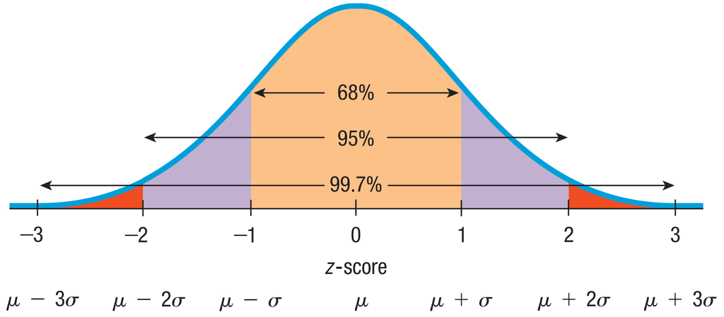

## The Empirical Rule

Let us see how the data we looked at today fits with the empirical rule. The following gives the theoretical and the actual proportion of the data within *one* standard deviation of the mean.

| Variable | Empirical Rule | Actual |
| --- | --- | --- |
| `Score` | 0.68 | 0.39 |
| `enroll90` | 0.68 | 0.63 |
| `enroll00` | 0.68 | 0.78 |
| `vcrime00` | 0.68 | 0.76 |

As expeced, the approximation is better for data distributions that are more bell-shaped. The less bell-shaped the distribution is, the worse the approximation.

## Chebyshev’s Inequality

While the empirical rule gives approximate bounds for specified proportions of the data, Chebyshev’s inequality gives absolute bounds (bounds that must be met).

According to the Chebyshev’s inequality, at least:

$$1 - \frac{1}{k^2}$$

of the data are within $k$ standard deviations of the mean.

## Chebyshev’s Inequality

- At least 0% of the data must be within one standard deviation of the mean (between $\mu - 1\sigma$ and $\mu + 1\sigma$).
- At least 75% of the data must be within two standard deviation of the mean (between $\mu - 2\sigma$ and $\mu + 2\sigma$).
- At least 88.89% of the data must be within three standard deviation of the mean (between $\mu - 3\sigma$ and $\mu + 3\sigma$).
- And so on…

**Note:** These are guaranteed bounds.

## Chebyshev’s Inequality

Let us see how the data we looked at today fits with the empirical rule. The following gives the theoretical and the actual proportion of the data within *two* standard deviations of the mean.

| Variable | Empirical Rule | Chebyshev | Actual |
| --- | --- | --- | --- |
| `Score` | 0.95 | 0.75 | 1.00 |
| `enroll90` | 0.95 | 0.75 | 0.96 |
| `enroll00` | 0.95 | 0.75 | 0.98 |
| `vcrime00` | 0.95 | 0.75 | 0.98 |

As expected, the approximation is better for data distributions that are more bell-shaped. The less bell-shaped the distribution is, the worse the approximation.

## Take-Aways About These Approximations

Here are some things to take away from this discussion:

- The empirical rule is an approximation.
- Chebyshev’s inequality is guaranteed.
- The empirical rule says *approximately* 95% of the data are within $2\sigma$ of $\mu$.
- Chebyshev’s inequality says at least 75% of the data are within $2\sigma$ of $\mu$.
- The empirical rule is better when the data are bell-shaped.
- Chebyshev’s inequality is guaranteed, regardless of the data distribution
- The empirical rule is useful in applied statistics.
- Chebyshev’s inequality is useful in proofs.